# Exercise 0

Due date: 2022-01-25

This is the zeroth exercise just to review python and show you how to submit exercises.

File name convention: For group 42 and memebers Richard Stallman and Linus Torvalds it would be "00_Exercise0_Goup42_Stallman_Torvalds.pdf". Just give yourself a funny group name for this exercise!

Submission via blackboard everyone individually (for this exercise).

```python
group_name = "Just Me"
group_members = ["Suzanne Rosenzweig"]
```

[Run in Google Colab](https://colab.research.google.com/github/UAPH4582/PH482_582_Sp22/blob/main/Exercises/00_PythonPrimer.ipynb)

## Functions

### Task 1

Write a function `subtract` that takes two numbers `a` and `b` and returns `a-b`.

```python
# your code goes below
# ↓↓↓↓↓↓↓↓↓↓↓↓↓↓↓↓↓↓↓↓↓↓↓↓↓↓↓↓↓↓↓
```

```python
def subtract(a, b):
    return a-b
```

```python
# ↑↑↑↑↑↑↑↑↑↑↑↑↑↑↑↑↑↑↑↑↑↑↑↑↑↑↑↑↑↑↑
# your code goes above this
```

```python
# testing if the function is working
subtract(3, 5) == -2
```

```
True
```

### Task 2

a) Write a function `fac_it` that calculates the factorial in an iterative way.  
b) (optional) Write a function `fac_rec` that computes the factorial in a recursive way.

**Hints**  
a) Set a variable `fac = 1`, loop over `i in range(2,n+1)` and in the loop muliply `fac` by `i`.  
b) The trick is to set the cases for `n=0` and `n=1` and then call something like `n*fac_rec(n-1)`.

```python
# your code goes below
# ↓↓↓↓↓↓↓↓↓↓↓↓↓↓↓↓↓↓↓↓↓↓↓↓↓↓↓↓↓↓↓
```

```python
import numpy as np
```

```python
def fac_it(n):
  assert(n >= 0), "ERROR: Function cannot handle negative values. Please enter a positive integer."
  assert(isinstance(n,int)), "ERROR: Function cannot handle decimal values. Please enter a positive integer."
  # create an array of elements [1, 2, ..., n-1, n]
  fac = np.arange(1,n+1)
  # multiple all elements in the array together
  fac = np.prod(fac)
  return fac
```

```python
def fac_rec(n):
  assert(n >= 0), "ERROR: Function cannot handle negative values. Please enter a positive integer."
  assert(isinstance(n,int)), "ERROR: Function cannot handle decimal values. Please enter a positive integer."
  # when n reaches the value 1, return 1
  if (n == 1) or (n==0): return 1
  # if n is greater than 1,
  else:
    return n * fac_rec(n-1)
```

```python
print(fac_rec(3) == 6)
print(fac_it(3) == 6)
```

```
True
True
```

```python
# ↑↑↑↑↑↑↑↑↑↑↑↑↑↑↑↑↑↑↑↑↑↑↑↑↑↑↑↑↑↑↑
# your code goes above this
```

## Numpy

```python
import numpy as np
```

You can read about this dataset [here](https://inria.github.io/scikit-learn-mooc/python_scripts/datasets_california_housing.html). `X` are some features of houses and `y` is the price of the houses in 100k$.

```python
from sklearn.datasets import fetch_california_housing

california_housing = fetch_california_housing()
```

```python
california_housing.keys()
```

```
dict_keys(['data', 'target', 'frame', 'target_names', 'feature_names', 'DESCR'])
```

```python
X = california_housing['data']
y = california_housing['target']
```

### Task 3

1) Find out how many instances there are in `X` and `y`. You can use `.shape` or `len`.

```python
# your code goes below
# ↓↓↓↓↓↓↓↓↓↓↓↓↓↓↓↓↓↓↓↓↓↓↓↓↓↓↓↓↓↓↓
```

```python
len(X) # returns an integer
```

```
20640
```

```python
y.shape # returns a tuple
```

```
(20640,)
```

```python
# ↑↑↑↑↑↑↑↑↑↑↑↑↑↑↑↑↑↑↑↑↑↑↑↑↑↑↑↑↑↑↑
# your code goes above this
```

```python
# your code goes below
# ↓↓↓↓↓↓↓↓↓↓↓↓↓↓↓↓↓↓↓↓↓↓↓↓↓↓↓↓↓↓↓
```

```python
y_200k_mask = y > 2
y_200k_mask
```

```
array([ True,  True,  True, ..., False, False, False])
```

```python
# ↑↑↑↑↑↑↑↑↑↑↑↑↑↑↑↑↑↑↑↑↑↑↑↑↑↑↑↑↑↑↑
# your code goes above this
```

3) Use [`Counter`](https://docs.python.org/3/library/collections.html#collections.Counter) to find out how many houses are woth more than 200k$.

```python
from collections import Counter
```

```python
# your code goes below
# ↓↓↓↓↓↓↓↓↓↓↓↓↓↓↓↓↓↓↓↓↓↓↓↓↓↓↓↓↓↓↓
```

```python
Counter(y_200k_mask)
```

```
Counter({True: 8709, False: 11931})
```

```python
# ↑↑↑↑↑↑↑↑↑↑↑↑↑↑↑↑↑↑↑↑↑↑↑↑↑↑↑↑↑↑↑
# your code goes above this
```

By calling `arr[mask]` you can extract only those items from a numpy array where `mask` is `True`.  
4) Put all `X` where the price is in `X_200k` and the corresponding `y` in `y_200k`.

```python
# your code goes below
# ↓↓↓↓↓↓↓↓↓↓↓↓↓↓↓↓↓↓↓↓↓↓↓↓↓↓↓↓↓↓↓
```

```python
X_200k = X[y_200k_mask]
y_200k = y[y_200k_mask]
```

```python
# ↑↑↑↑↑↑↑↑↑↑↑↑↑↑↑↑↑↑↑↑↑↑↑↑↑↑↑↑↑↑↑
# your code goes above this
```

## Pandas Dataframes

```python
from sklearn.datasets import fetch_california_housing

california_housing_df = fetch_california_housing(as_frame=True)
```

```python
X_df = california_housing_df['data']
y_df = california_housing_df['target']
```

### Task 4

1) Get a [description](https://pandas.pydata.org/pandas-docs/stable/reference/api/pandas.DataFrame.describe.html) of the `X_df` and `y_df`.

```python
# your code goes below
# ↓↓↓↓↓↓↓↓↓↓↓↓↓↓↓↓↓↓↓↓↓↓↓↓↓↓↓↓↓↓
```

```python
X_df.describe()
```

|  | MedInc | HouseAge | AveRooms | AveBedrms | Population | AveOccup | Latitude | Longitude |
| --- | --- | --- | --- | --- | --- | --- | --- | --- |
| count | 20640.000000 | 20640.000000 | 20640.000000 | 20640.000000 | 20640.000000 | 20640.000000 | 20640.000000 | 20640.000000 |
| mean | 3.870671 | 28.639486 | 5.429000 | 1.096675 | 1425.476744 | 3.070655 | 35.631861 | -119.569704 |
| std | 1.899822 | 12.585558 | 2.474173 | 0.473911 | 1132.462122 | 10.386050 | 2.135952 | 2.003532 |
| min | 0.499900 | 1.000000 | 0.846154 | 0.333333 | 3.000000 | 0.692308 | 32.540000 | -124.350000 |
| 25% | 2.563400 | 18.000000 | 4.440716 | 1.006079 | 787.000000 | 2.429741 | 33.930000 | -121.800000 |
| 50% | 3.534800 | 29.000000 | 5.229129 | 1.048780 | 1166.000000 | 2.818116 | 34.260000 | -118.490000 |
| 75% | 4.743250 | 37.000000 | 6.052381 | 1.099526 | 1725.000000 | 3.282261 | 37.710000 | -118.010000 |
| max | 15.000100 | 52.000000 | 141.909091 | 34.066667 | 35682.000000 | 1243.333333 | 41.950000 | -114.310000 |

```python
y_df.describe()
```

```
count    20640.000000
mean         2.068558
std          1.153956
min          0.149990
25%          1.196000
50%          1.797000
75%          2.647250
max          5.000010
Name: MedHouseVal, dtype: float64
```

```python
# ↑↑↑↑↑↑↑↑↑↑↑↑↑↑↑↑↑↑↑↑↑↑↑↑↑↑↑↑↑↑↑
# your code goes above this
```

2) Get all elements of the dataframe where the price is >= 200k$. You don't have to convert anything to numpy arrays.

```python
# your code goes below
# ↓↓↓↓↓↓↓↓↓↓↓↓↓↓↓↓↓↓↓↓↓↓↓↓↓↓↓↓↓↓
```

```python
X_df[y_df >= 2]
```

|  | MedInc | HouseAge | AveRooms | AveBedrms | Population | AveOccup | Latitude | Longitude |
| --- | --- | --- | --- | --- | --- | --- | --- | --- |
| 0 | 8.3252 | 41.0 | 6.984127 | 1.023810 | 322.0 | 2.555556 | 37.88 | -122.23 |
| 1 | 8.3014 | 21.0 | 6.238137 | 0.971880 | 2401.0 | 2.109842 | 37.86 | -122.22 |
| 2 | 7.2574 | 52.0 | 8.288136 | 1.073446 | 496.0 | 2.802260 | 37.85 | -122.24 |
| 3 | 5.6431 | 52.0 | 5.817352 | 1.073059 | 558.0 | 2.547945 | 37.85 | -122.25 |
| 4 | 3.8462 | 52.0 | 6.281853 | 1.081081 | 565.0 | 2.181467 | 37.85 | -122.25 |
| ... | ... | ... | ... | ... | ... | ... | ... | ... |
| 20545 | 3.7452 | 26.0 | 5.113951 | 1.011715 | 2199.0 | 2.341853 | 38.55 | -121.75 |
| 20565 | 2.4167 | 22.0 | 5.938865 | 1.231441 | 808.0 | 3.528384 | 38.65 | -121.70 |
| 20566 | 4.3487 | 29.0 | 5.930712 | 1.026217 | 1554.0 | 2.910112 | 38.65 | -121.84 |
| 20573 | 5.6790 | 20.0 | 6.401274 | 1.070064 | 457.0 | 2.910828 | 38.56 | -122.05 |
| 20578 | 2.8542 | 37.0 | 5.253731 | 0.970149 | 238.0 | 3.552239 | 38.84 | -121.81 |

8755 rows × 8 columns

```python
# ↑↑↑↑↑↑↑↑↑↑↑↑↑↑↑↑↑↑↑↑↑↑↑↑↑↑↑↑↑↑↑
# your code goes above this
```

3) Plot the [histogram](https://pandas.pydata.org/pandas-docs/stable/reference/api/pandas.DataFrame.hist.html) of `X_df` and `y_df`.

```python
# your code goes below
# ↓↓↓↓↓↓↓↓↓↓↓↓↓↓↓↓↓↓↓↓↓↓↓↓↓↓↓↓↓↓↓
```

```
array([[<AxesSubplot:title={'center':'MedInc'}>,
        <AxesSubplot:title={'center':'HouseAge'}>,
        <AxesSubplot:title={'center':'AveRooms'}>],
       [<AxesSubplot:title={'center':'AveBedrms'}>,
        <AxesSubplot:title={'center':'Population'}>,
        <AxesSubplot:title={'center':'AveOccup'}>],
       [<AxesSubplot:title={'center':'Latitude'}>,
        <AxesSubplot:title={'center':'Longitude'}>, <AxesSubplot:>]],
      dtype=object)
```

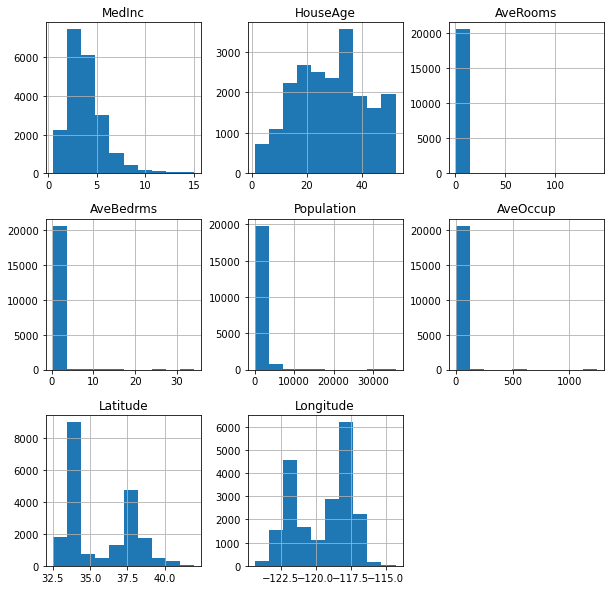

```python
X_df.hist(figsize=(10,10))
```

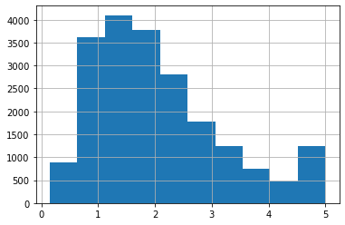

```python
y_df.hist()
```

```python
# ↑↑↑↑↑↑↑↑↑↑↑↑↑↑↑↑↑↑↑↑↑↑↑↑↑↑↑↑↑↑↑
# your code goes above this
```

# Solutions

```python
def fac_rec(n):
  if n == 0:
    return 1
  elif n == 1:
    return 1
  else:
    return n*fac_rec(n-1)
```